# Model comparison

## Overview

> By the end of these workshops and your own reading, you should be able to
- Describe the meaning of and calculate likelihood
- Using unexplained variance to assess model fit
- Describe the limitations of \(R^2\) as model fit statistic
- Use likelihood ratio test (*F*-test) and information criteria to compare nested models

## Why do we need model comparion?

> “All models are wrong, but some are useful”

> George E.P. Box
- Models are statistical representations of a hypothesis.
- We want to compare the usefulness of alternative models.
- Can my model accurately predict future outcomes?
- Parsimony: As complex as necessary, as simple as possible.

## Ockham’s razor: the principle of parsimony

- Is it worth assuming a more complex model?
- Philosopher William of Ockham (1285-1347/49):

> “Plurality should not be posited without necessity.”

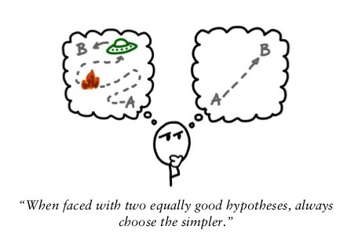

- Precedence to simplicity: of two competing theories, the simpler explanation of an entity is to be preferred.
- We don’t assume more complex theories, if there is not sufficient evidence.

## Probabilistic generative models

- In any statistical analysis, we assume our data are drawn from some probability distribution.
- This is what we mean by *statistical model*, a *probabilistic generative model* like

\[ y_i \sim \mathcal{N}(\mu_i, \sigma^2), \mu_i = \beta_0 + \beta_1 \cdot x_i \]

- A model of the *statistical population* could also be described as the true generative model.
- In our analysis, we aim to find a good, or good enough, model of the population.

## Model evaluation via likelihood

- Tests if the data are compatible with the model: calculate the probability of the data according to the model.
- If the probability of observing the data is higher in model \(\mathcal{M}_0\) than in another \(\mathcal{M}_1\), which model is more compatible with the data?
- The probability of the data according to the model is the model’s *likelihood*.

## Probabilistic model

> A possible model of each observed outcome \(y_i\) is

\[ y_i \sim N(\mu, \sigma^2)\\ \text{for } i \in 1\dots n, \]

> We are modelling \(y\) as normally distributed with two unknowns, the mean \(\mu\) and standard deviation \(\sigma\).

## Likelihood

> Probability of the observed values, \(y_1, y_2, y_3\dots y_n\), assuming values for \(\mu\) and \(\sigma\) (based on a particular model).

\[ P(y_1\dots y_n\mid\mu, \sigma) \]

> We assume that all \(y\)s are conditionally independent of one another, so the joint probability is their product:

\[ P(y_1\dots y_n\mid\mu, \sigma) = \prod_\text{i=1}^n P(y_i\mid \mu, \sigma). \]

## Likelihood

> Replace \(\mu\) and \(\sigma\) with their *maximum likelihood estimates* \(\hat\mu\) and \(\hat\sigma\):

\[ P(y_1\dots y_n\mid\hat\mu, \hat\sigma) = \prod_\text{i=1}^n P(y_i\mid \hat\mu, \hat\sigma). \]

> Product will be a very small number (i.e. numeric underflow) cause probabilities are \(0 > p < 1\), so we use logarithm:

\[ \text{log} \left( P(y_1\dots y_n\mid\hat\mu, \hat\sigma) \right) = \sum_\text{i=1}^n \text{log } P(y_i\mid \hat\mu, \hat\sigma), \]

> Logarithm is turning product \(\prod\) into sum \(\sum\). Cause `log(.5) + log(.2)` is the same as `log(.5 * .2)`.

## Likelihood

```r
model_0 <- lm(log_rt ~ 1, data = blomkvist)
mu_hat <- coef(model_0) # MLE of mu
sigma_hat <- sigma(model_0) # MLE of sigma
```

```r
# log probability of an observed outcome for given MLEs.
logp <- dnorm(blomkvist$log_rt, mean = mu_hat, sd = sigma_hat, log = TRUE)
sum(logp) # sum of log probabilities is the log likelihood
```

```
[1] -17.6
```

```r
logLik(model_0)
```

```
'log Lik.' -17.6 (df=2)
```

> Work through exercise script: `exercises/log_likelihood_1.R`

## Likelihood

```r
select(blomkvist, id, log_rt, sex)
```

```
# A tibble: 266 × 3
     id log_rt sex
  <dbl>  <dbl> <chr>
1     1   6.55 male
2     2   6.15 female
3     3   6.46 female
4     4   6.56 female
5     5   6.41 male
# … with 261 more rows
```

> Using the `sex` variable, the potential model of the log rt data is

\[ \begin{aligned} \text{logrt}_i &\sim N(\mu_i, \sigma^2),\text{ for } i \in 1\dots n,\\ \mu_i&= \beta_0 + \beta_\text{sex} \cdot \text{sex}_i, \end{aligned} \]

> We are modelling log rt as normally distributed as a function of `sex`, and with an equal variance \(\sigma^2\).

## Likelihood

> Give \(\hat\beta_0,\hat\beta_\text{sex},\hat\sigma\), we can calculate the probability of the observed values:

\[ P(\text{logrt}_1\dots \text{logrt}_n\mid \text{sex}_1\dots \text{sex}_n,\beta_0,\beta_\text{sex},\sigma) = \prod_\text{i=1}^n P(\text{logrt}_i\mid \text{sex}_i,\beta_0,\beta_\text{sex},\sigma) \]

> The log likelihood of the model is

\[ \sum_\text{i=1}^n\text{ log} P(\text{logrt}_i\mid \text{sex}_i,\beta_0,\beta_\text{sex},\sigma). \]

## Likelihood

```r
model_1 <- lm(log_rt ~ sex, data = blomkvist)
mu_hat <- predict(model_1) # mu_hat = beta_0 + beta_sex * sex
sigma_hat <- sigma(model_1)
```

```r
logp <- dnorm(blomkvist$log_rt, mean = mu_hat, sd = sigma_hat, log = TRUE)
sum(logp)
```

```
[1] -13.3
```

```r
logLik(model_1)
```

```
'log Lik.' -13.3 (df=3)
```

> Work through exercise script: `exercises/log_likelihood_2.R`

## Compare log likelihoods

> Which model are the data more compatible with?

```r
logLik(model_0) # L_0
```

```
'log Lik.' -17.6 (df=2)
```

```r
logLik(model_1) # L_1
```

```
'log Lik.' -13.3 (df=3)
```

> Let’s denote these log likelihoods as log \(\mathcal{L}_0\) and log \(\mathcal{L}_1\):

\[ \begin{aligned} \text{log} \left(\frac{\mathcal{L}_1}{\mathcal{L}_0}\right)&=\text{log}\mathcal{L}_1-\text{log}\mathcal{L}_0\\ &=-13.3--17.6\\ &=4.3 \end{aligned} \]

> Including `sex` appears to increase the log likelihood.

> Work through exercise script: `exercises/compare_log_lik.R`

## Calculating \(R^2\)

is the ratio of ESS (explained sum of squares) and TSS (total sum of squares) for which we need to work out the RSS (residual sum of squares; based on residuals):

\[ \underbrace{\sum_{i=1}^n(y_i-\bar{y})^2}_\text{TSS} = \underbrace{\sum_{i=1}^n(\hat\mu_i-\bar{y})^2}_\text{ESS} + \underbrace{\sum_{i=1}^n(y_i-\hat\mu_i)^2}_\text{RSS} \]

## Residuals

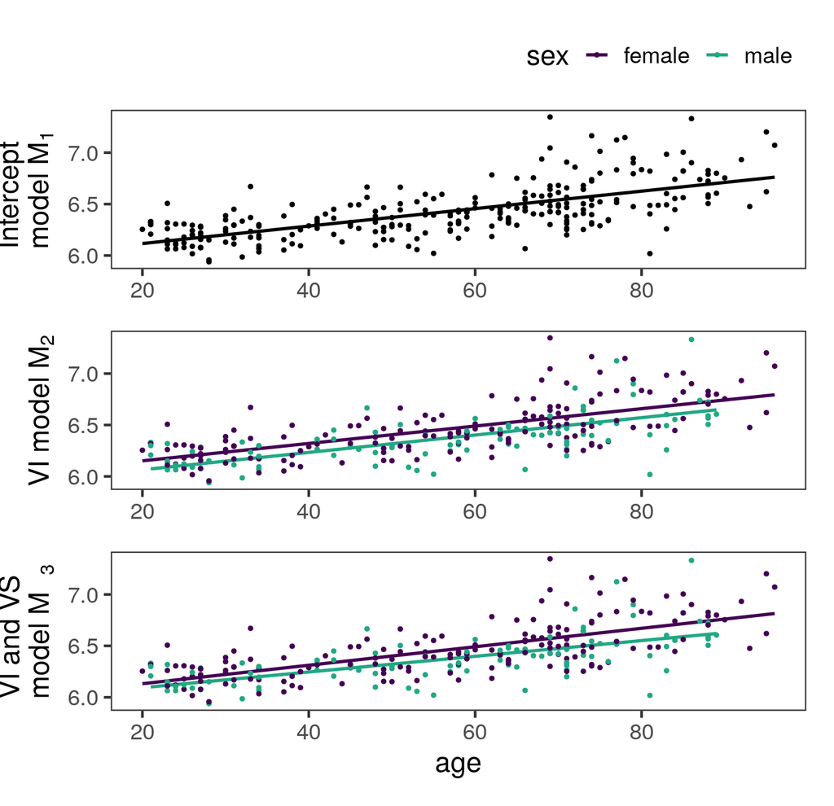

## Residuals

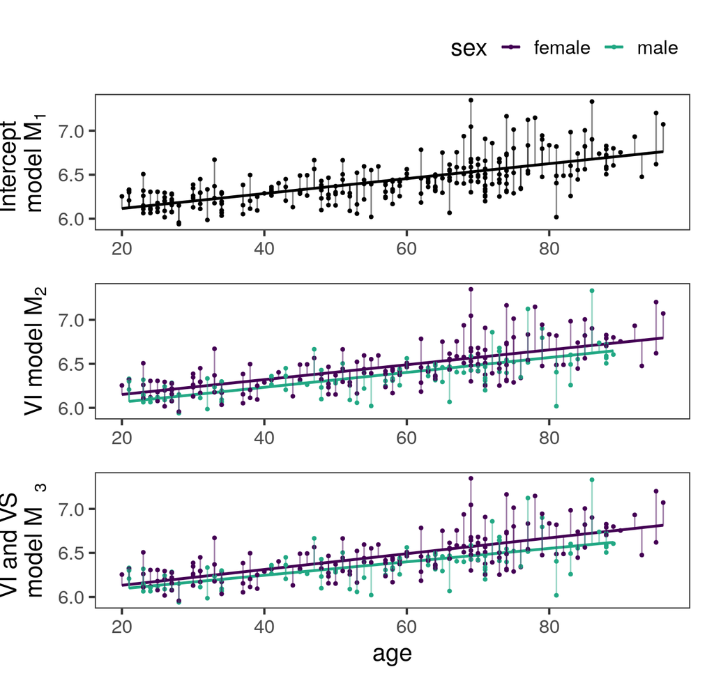

- Residuals are the unexplained (residual) variance: error in the modelling results.
- Distance between observed (\(y\)) and predicted rt (\(\hat{\mu}\))

\[ \epsilon = y - \hat{\mu} \]

- The closer the residuals are to 0, the lower the prediction error.

## Residuals

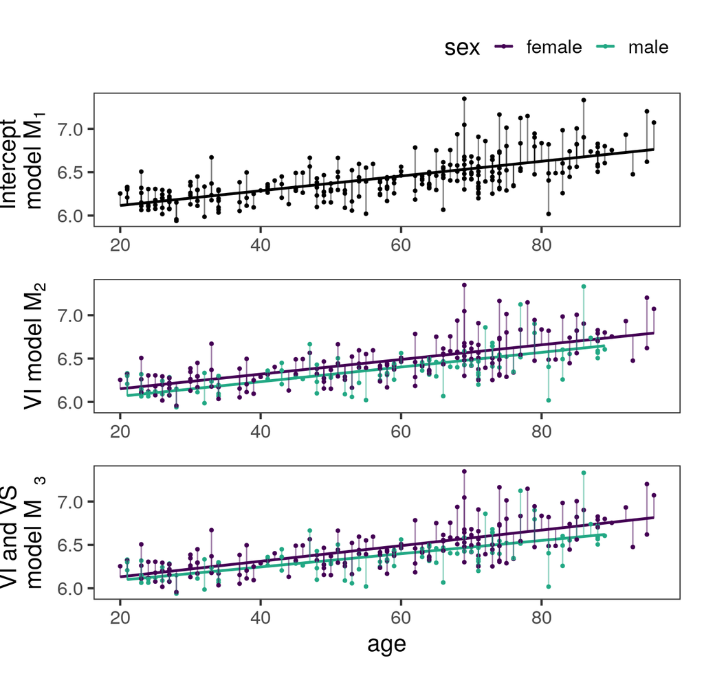

```r
mutate(blomkvist,
       mu_hat = predict(model),
       resid_1 = log_rt - mu_hat,
       resid_2 = residuals(model)) %>%
  select(log_rt, mu_hat, resid_1, resid_2)
```

```
# A tibble: 266 × 4
  log_rt mu_hat resid_1 resid_2
   <dbl>  <dbl>   <dbl>   <dbl>
1   6.55   6.58 -0.0286 -0.0286
2   6.15   6.28 -0.131  -0.131
3   6.46   6.51 -0.0500 -0.0500
4   6.56   6.72 -0.153  -0.153
5   6.41   6.50 -0.0890 -0.0890
# … with 261 more rows
```

Work through exercise script: `exercises/residuals.R`

## Residual sum of squares

The sum of squared residuals when using the maximum likelihood estimators is

\[ \begin{aligned} \text{RSS}&=\sum_\text{i=1}^n \mid y_i - (\hat\beta_0+\hat\beta_1\cdot x_i)\mid^2,\\ &=\sum_\text{i=1}^n\mid y_i-\hat{\mu}_i\mid^2 \end{aligned} \]

RSS is a measure of how much variance in the data is not explained by the model; or the model’s lack of fit.

## Residual sum of squares

```r
# RSS: total of unexplained variance
(rss <- sum(residuals(model)^2))
```

```
[1] 9.2
```

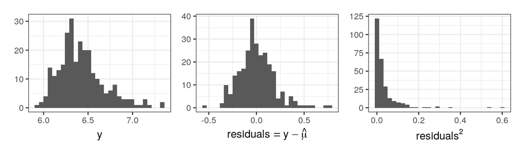

## Explained sum of squares

ESS is sum of squared differences of predicted data and sample mean.

\[ \text{ESS} = \sum_{i=1}^n(\hat\mu_i-\bar{y})^2 \]

Predicted mean value \(\hat\mu_i\) for each observation \(i\):

\[ \hat\mu_i = \hat\beta_0 + \hat\beta_1 \cdot x_{i} \]

```r
(mu_hat <- predict(model))[1:10]
```

```
   1    2    3    4    5    6    7    8    9   10
6.58 6.28 6.51 6.72 6.50 6.44 6.22 6.39 6.57 6.38
```

\(\bar{y}\) is the mean of the sample.

```r
(y_bar <- mean(blomkvist$log_rt))
```

```
[1] 6.42
```

```r
# ESS: explained sum of squares
(ess <- sum( (mu_hat - y_bar)^2 ))
```

```
[1] 8.58
```

## \(R^2\): coefficient of determination

calculated on the basis of TSS which is the sum of ESS and RSS

\[ \underbrace{\sum_{i=1}^n(y_i-\bar{y})^2}_\text{TSS} = \underbrace{\sum_{i=1}^n(\hat\mu_i-\bar{y})^2}_\text{ESS} + \underbrace{\sum_{i=1}^n(y_i-\hat\mu_i)^2}_\text{RSS} \]

```r
(tss <- ess + rss)
```

```
[1] 17.8
```

## \(R^2\): coefficient of determination

- Ability of a model to predict the outcome variable.
- Proportion of the variability in the outcome attributed to the predictor(s).
- Routinely used as measure of model fit.

\[ R^2 = \frac{\text{ESS}}{\text{TSS}} \]

> Work through script: `exercises/rsquared.R`

```r
ess / tss
```

```
[1] 0.482
```

```r
summary(model)$r.sq
```

```
[1] 0.482
```

## Adjusted \(R^2\)

- The value of \(R^2\) necessarily increases, or does not decrease, as we add more predictors to the model, even if the true values of the coefficients for these predictors are zero.
- Overfitting: Complex models explain more variance but may make over optimistic predictions (Gelman, Hill, and Vehtari 2020).
- Example: brain size and body mass for seven primate species (from McElreath 2016).

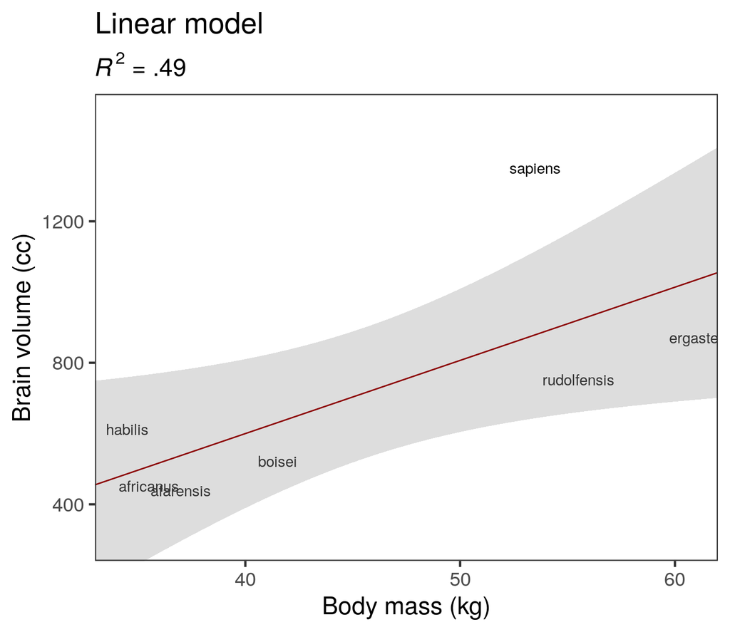

## Adjusted \(R^2\)

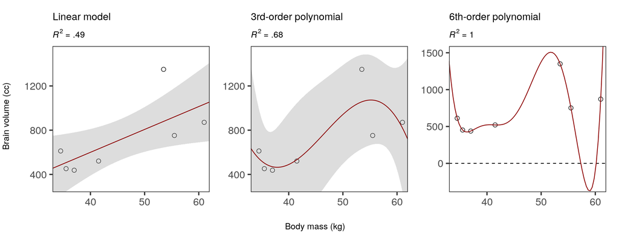

## Adjusted \(R^2\)

To overcome this spurious increase in \(R^2\), the following adjustment is applied.

## Adjusted \(R^2\)

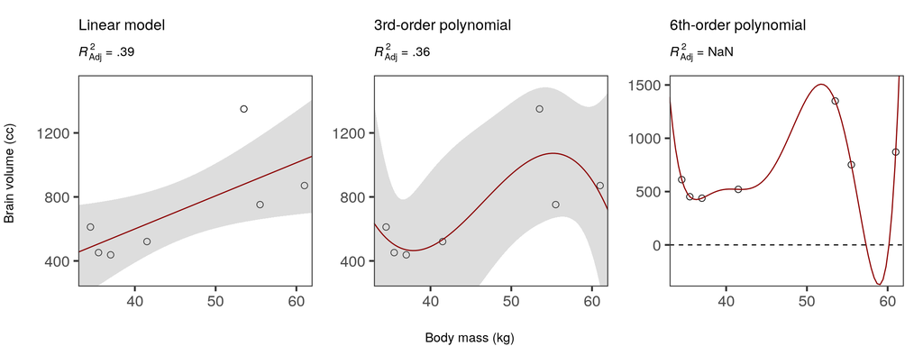

## \(R^2\) and Adjusted \(R^2\) with `lm`

```r
# Specify models
model_1 <- lm(log_rt ~ sex, data = blomkvist)
model_2 <- lm(log_rt ~ sex + age, data = blomkvist)
```

From the `lm` objects, \(R^2\) and \(R_\text{Adj}^2\) can be obtained using `summary`

```r
# Generate model summary
summary_model_1 <- summary(model_1)
summary_model_2 <- summary(model_2)
```

Because \(n \gg K\), the penalty term is (very) close to 1.0 and the adjustment is minimal.

Do exercise `exercises/adjrsquared.R`

```r
summary_model_1$r.squared
```

```
[1] 0.0316
```

```r
summary_model_2$r.squared
```

```
[1] 0.48
```

```r
summary_model_1$adj.r.squared
```

```
[1] 0.0279
```

```r
summary_model_2$adj.r.squared
```

```
[1] 0.476
```

## Model comparison

- \(R^2=0\) is only true if \(\beta_1=\beta_2=\dots\beta_k=0\).
- When all coefficients are simultaneously zero, we are essentially saying that the following two models are identical.

\[ \begin{aligned} \mathcal{M}_0:& y_i \sim N(\hat\mu, \sigma^2), \hat\mu_i = \beta_0\\ \mathcal{M}_1:& y_i \sim N(\hat\mu, \sigma^2), \hat\mu_i = \beta_0 + \sum_{k=1}^K \beta_k \cdot x_{ki} \end{aligned} \]

> \(\text{ for } i \in 1\dots n\)

## Model comparison

- Null hypothesis is that the following two models are identical:

\[ \begin{aligned} \mathcal{M}_0:& \text{logrt}_i \sim N(\hat\mu, \sigma^2), \hat\mu_i = \beta_0\\ \mathcal{M}_1:& \text{logrt}_i \sim N(\hat\mu, \sigma^2), \hat\mu_i = \beta_0 + \beta_\text{sex} \cdot \text{sex}_{i} \end{aligned} \]

> \(\text{ for } i \in 1\dots n\)
- In other words, the null hypothesis is that adding the predictor \(\text{sex}\) in \(\mathcal{M}_1\) does not explain any variance in the data that model \(\mathcal{M}_0\) was already accounting for.

## Model comparison

- Nested normal linear models can be compared using F test.
- Under the null hypothesis that these two models are identical, and so the coefficients for all predictors are simultaneously zero, we have

\[ \underbrace{\frac{(\text{RSS}_0-\text{RSS}_1)/K}{\text{RSS}_1/(n - K - 1)}}_\text{F-statistic} \sim F(K, n-K-1) \]

- We can compare two models \(\mathcal{M}_1\) and \(\mathcal{M}_0\) (with \(K_1\) and \(K_0\) predictors, respectively) where \(\mathcal{M}_0\) is *nested* in \(\mathcal{M}_1\):
  - \(K_0 < K_1\)
  - all the \(K_0\) predictors in \(\mathcal{M}_0\) are also presented in \(\mathcal{M}_1\)

## F distribution

```r
df1 <- seq(1, 21, 3)
df2 <- 300
F_grid <- seq(0, 5, .1)
```

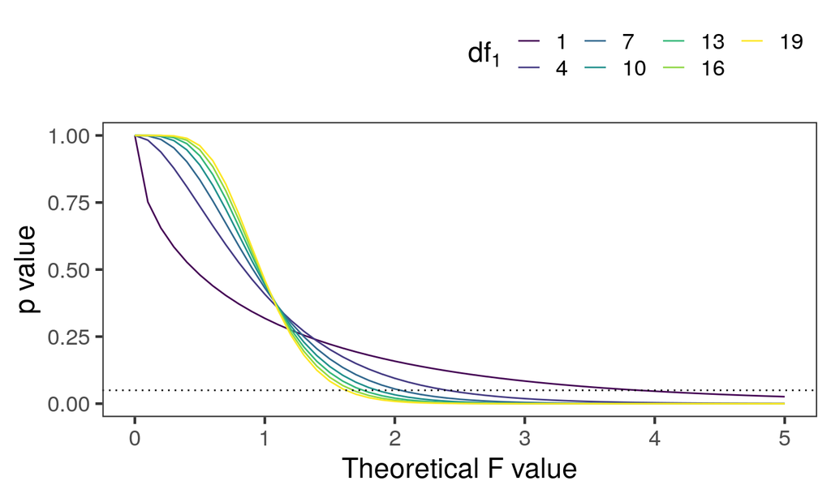

```r
df1 <- 5
df2 <- seq(3, 300, 30)
F_grid <- seq(0, 5, .1)
```

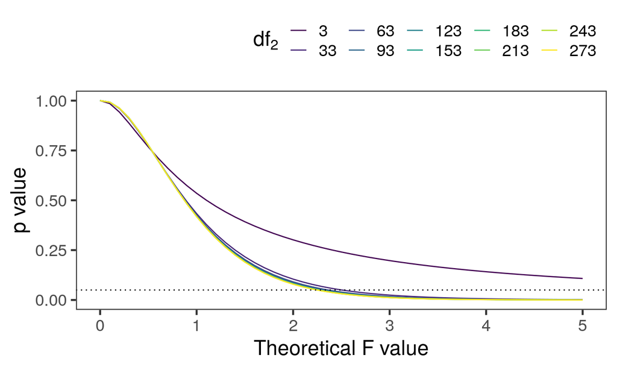

## Model comparison

> The null hypothesis that \(R^2=0\) can be obtained using `anova` to compare `model_1` against `model_0`.

```r
# Specify models
model_0 <- lm(log_rt ~ 1, data = blomkvist)
model_1 <- lm(log_rt ~ sex, data = blomkvist)
```

```r
# Compare models
anova(model_0, model_1)
```

```
Analysis of Variance Table

Model 1: log_rt ~ 1
Model 2: log_rt ~ sex
  Res.Df  RSS Df Sum of Sq   F Pr(>F)
1    265 17.8
2    264 17.2  1     0.561 8.6 0.0037
```

## Model comparison

> The null hypothesis that \(R^2=0\) can be obtained using `anova` to compare `model_1` against `model_0`.

```r
# Specify models
model_0 <- lm(log_rt ~ 1, data = blomkvist)
model_1 <- lm(log_rt ~ sex, data = blomkvist)
```

```r
# Compare models
anova(model_0, model_1)
```

```
Analysis of Variance Table

Model 1: log_rt ~ 1
Model 2: log_rt ~ sex
  Res.Df  RSS Df Sum of Sq   F Pr(>F)
1    265 17.8
2    264 17.2  1     0.561 8.6 0.0037
```

- `RSS` are TSS and RSS of `model_1`.
- TSS of `model_0`: in model with no predictors, TSS and RSS are identical.
- ESS is `Sum of Sq` / difference of `RSS`s:

```r
mu_hat <- predict(model_1)
y_bar <- mean(blomkvist$log_rt)
sumdiff <- mu_hat - y_bar
(ess <- sum(sumdiff^2))
```

```
[1] 0.561
```

## Model comparison

> The null hypothesis that \(R^2=0\) can be obtained using `anova` to compare `model_1` against `model_0`.

```r
# Specify models
model_0 <- lm(log_rt ~ 1, data = blomkvist)
model_1 <- lm(log_rt ~ sex, data = blomkvist)
```

```r
# Compare models
anova(model_0, model_1)
```

```
Analysis of Variance Table

Model 1: log_rt ~ 1
Model 2: log_rt ~ sex
  Res.Df  RSS Df Sum of Sq   F Pr(>F)
1    265 17.8
2    264 17.2  1     0.561 8.6 0.0037
```

- `Df` and bottom value of `Res.Df` are degrees of freedom

```r
K <- 1
n <- nrow(blomkvist)
c(K, n - K - 1)
```

```
[1]   1 264
```

- `ess` and `rss` are divided for F:

```r
rss <- sum(residuals(model_1)^2)
(f_stat <- (ess/K) / (rss/(n - K - 1)))
```

```
[1] 8.6
```

## Model comparison

> The null hypothesis that \(R^2=0\) can be obtained using `anova` to compare `model_1` against `model_0`.

```r
# Specify models
model_0 <- lm(log_rt ~ 1, data = blomkvist)
model_1 <- lm(log_rt ~ sex, data = blomkvist)
```

```r
# Compare models
anova(model_0, model_1)
```

```
Analysis of Variance Table

Model 1: log_rt ~ 1
Model 2: log_rt ~ sex
  Res.Df  RSS Df Sum of Sq   F Pr(>F)
1    265 17.8
2    264 17.2  1     0.561 8.6 0.0037
```

- *p*-value is the probability of getting a greater / or equal F statistic in an F distribution with \(K\) and \(n - K - 1\) degrees of freedom.
- Cumulative distribution function of the F distribution `pf`

```r
pf(f_stat, K, n-K-1, lower.tail = FALSE)
```

```
[1] 0.00366
```

## F ratio

\[ \text{F} = \underbrace{\frac{\text{RSS}_0 - \text{RSS}_1}{\text{RSS}_1}}_\text{effect size} \cdot \underbrace{\frac{\text{df}_1}{\text{df}_0 -\text{df}_1}}_\text{sample size} = \frac{(\text{RSS}_0 - \text{RSS}_1)/(\text{df}_0 - \text{df}_1)}{\text{RSS}_1/\text{df}_1} \]

```r
# Dfs
df_0 <- model_0$df.residual
df_1 <- model_1$df.residual
c(df_0 - df_1, df_1)
```

```
[1]   1 264
```

```r
# RSS
rss_0 <- sum(residuals(model_0)^2)
rss_1 <- sum(residuals(model_1)^2)
```

```r
(rss_0 - rss_1)/(df_0 - df_1)
```

```
[1] 0.561
```

```r
((rss_0 - rss_1)/(df_0 - df_1))/(rss_1/df_1)
```

```
[1] 8.6
```

Complete exercise `exercises/modelcomparison.R`

## F distribution

```r
df1 <- K # Number of fixed effects
df2 <- n - K - 1
F_grid <- seq(0, 10, .1)
p_values <- pf(q = F_grid, df1 = df1, df2 = df2, lower.tail = F)
```

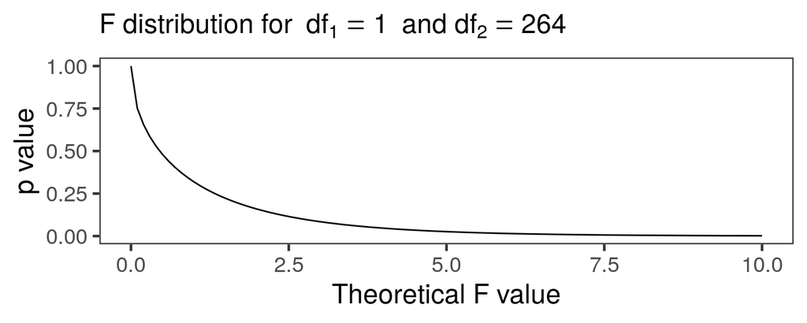

## F distribution

```r
df1 <- K # Number of fixed effects
df2 <- n - K - 1
F_grid <- seq(0, 10, .1)
p_values <- pf(q = F_grid, df1 = df1, df2 = df2, lower.tail = F)
```

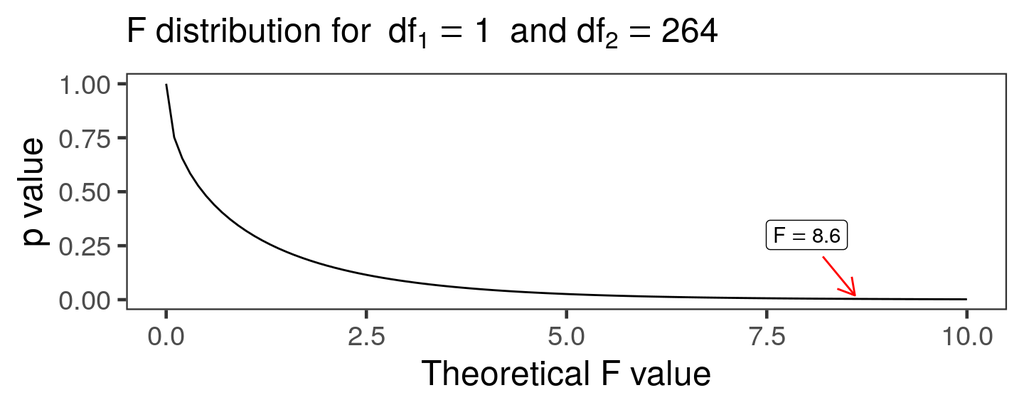

## F distribution

```r
df1 <- K # Number of fixed effects
df2 <- n - K - 1
F_grid <- seq(0, 10, .1)
p_values <- pf(q = F_grid, df1 = df1, df2 = df2, lower.tail = F)
```

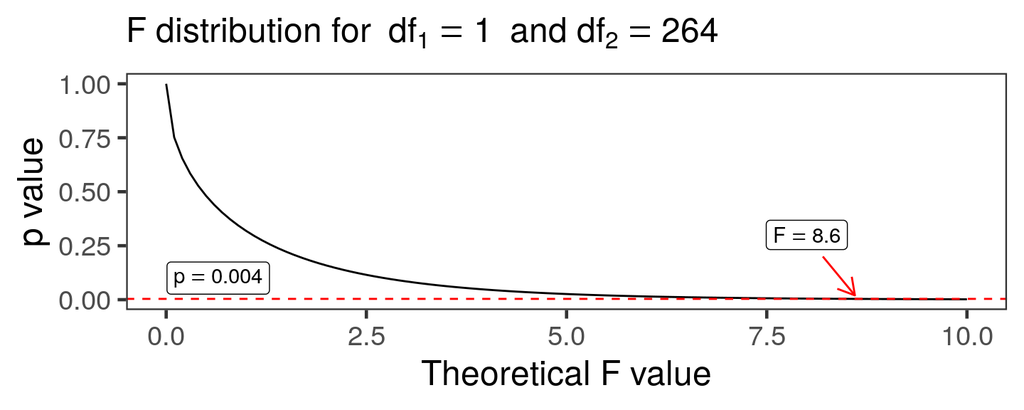

## F distribution

```r
df1 <- K # Number of fixed effects
df2 <- n - K - 1
F_grid <- seq(0, 10, .1)
p_values <- pf(q = F_grid, df1 = df1, df2 = df2, lower.tail = F)
```

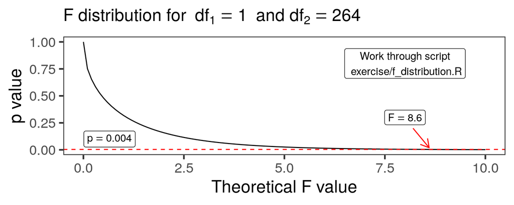

## Deviance information criterion (DIC)

where \(\hat{\mathcal{L}}\) is the likelihood of the model using the MLEs.

```r
deviance(model_1)
```

```
[1] 17.2
```

```r
rss_1
```

```
[1] 17.2
```

## Akaike and Bayesian Information Criterion

- Estimators of prediction error: relative quality of statistical models for data.
- Similar to \(R^2\), log likelihood will always increase when adding predictors, even if the true value of the coefficient is zero.
- Prevent overfitting by penalising models with more parameters: trade-off model fit (measured by \(\hat{\mathcal{L}}\)) and the number of parameters (\(K\)) in the model.

\[ \text{AIC} = 2 \cdot K - 2 \cdot \text{log}(\hat{\mathcal{L}})\\ \text{BIC} = \text{log}(n) \cdot K - 2\cdot \text{log}(\hat{\mathcal{L}})\\ \]

```r
ll <- as.vector(logLik(model_1))
K <- 3 # beta_0, beta_sex, sigma^2
(2 * K) - 2 * ll # AIC
```

```
[1] 32.7
```

```r
AIC(model_1)
```

```
[1] 32.7
```

```r
n <- nrow(blomkvist)
log(n) * K - 2 * ll # BIC
```

```
[1] 43.4
```

```r
BIC(model_1)
```

```
[1] 43.4
```

## Akaike and Bayesian Information Criterion

- Estimators of prediction error: relative quality of statistical models for data.
- Similar to \(R^2\), log likelihood will always increase when adding predictors, even if the true value of the coefficient is zero.
- Prevent overfitting by penalising models with more parameters: trade-off model fit (measured by \(\hat{\mathcal{L}}\)) and the number of parameters (\(K\)) in the model.

\[ \text{AIC} = 2 \cdot K - 2 \cdot \text{log}(\hat{\mathcal{L}})\\ \text{BIC} = \text{log}(n) \cdot K - 2\cdot \text{log}(\hat{\mathcal{L}})\\ \]

- AIC chooses models with better predictive ability; it tends to favour bigger models as the sample size increases.
- BIC is an approximation to Bayesian model comparison by Bayes factors.
- In many situations collecting more data will uncover more complexity in the process generating the data, in which case AIC may be more suitable.

## Comparing multiple nested models

… including the varying-intercepts (`model_3`) and the varying-intercepts and varying-slopes model (`model_4`).

```r
# Specify models
model_1 <- lm(log_rt ~ 1, data = blomkvist)
model_2 <- lm(log_rt ~ sex, data = blomkvist)
model_3 <- lm(log_rt ~ sex + age, data = blomkvist)
model_4 <- lm(log_rt ~ sex * age, data = blomkvist)
```

```r
# Compare models
anova(model_1, model_2, model_3, model_4)
```

```
Analysis of Variance Table

Model 1: log_rt ~ 1
Model 2: log_rt ~ sex
Model 3: log_rt ~ sex + age
Model 4: log_rt ~ sex * age
  Res.Df   RSS Df Sum of Sq      F  Pr(>F)
1    265 17.78
2    264 17.22  1      0.56  15.97 8.4e-05
3    263  9.25  1      7.97 226.81 < 2e-16
4    262  9.20  1      0.05   1.37    0.24
```

## Model evaluation made easy

```r
# Drop highest level predictor
drop1(model_4, scope = ~ sex * age, test = 'F')
```

```
Single term deletions

Model:
log_rt ~ sex * age
        Df Sum of Sq   RSS  AIC F value Pr(>F)
<none>                9.20 -887
sex      1      0.00  9.20 -889    0.03   0.86
age      1      5.46 14.66 -765  155.40 <2e-16
sex:age  1      0.05  9.25 -887    1.37   0.24
```

```r
# All you ever need :)
library(broom)
#library(broom.mixed) # for multilevel models
```

```r
tidy(model_4, conf.int = TRUE)
```

```
# A tibble: 4 × 7
  term        estimate std.error statistic   p.value conf.low conf.high
  <chr>          <dbl>     <dbl>     <dbl>     <dbl>    <dbl>     <dbl>
1 (Intercept)  5.95     0.0433     138.    2.62e-246  5.87     6.04
2 sexmale     -0.0120   0.0685      -0.175 8.61e-  1 -0.147    0.123
3 age          0.00898  0.000720    12.5   2.57e- 28  0.00756  0.0104
4 sexmale:age -0.00134  0.00115     -1.17  2.43e-  1 -0.00360  0.000919
```

```r
glance(model_4) %>% glimpse()
```

```
Rows: 1
Columns: 12
$ r.squared     <dbl> 0.482
$ adj.r.squared <dbl> 0.476
$ sigma         <dbl> 0.187
$ statistic     <dbl> 81.4
$ p.value       <dbl> 3.11e-37
$ df            <dbl> 3
$ logLik        <dbl> 70
$ AIC           <dbl> -130
$ BIC           <dbl> -112
$ deviance      <dbl> 9.2
$ df.residual   <int> 262
$ nobs          <int> 266
```

```r
augment(model_4)
```

```
# A tibble: 266 × 9
  log_rt sex      age .fitted  .resid    .hat .sigma  .cooksd .std.resid
   <dbl> <chr>  <dbl>   <dbl>   <dbl>   <dbl>  <dbl>    <dbl>      <dbl>
1   6.55 male      84    6.58 -0.0286 0.0280   0.188 0.000172     -0.155
2   6.15 female    37    6.28 -0.131  0.0118   0.188 0.00147      -0.702
3   6.46 female    62    6.51 -0.0500 0.00658  0.188 0.000118     -0.268
4   6.56 female    85    6.72 -0.153  0.0181   0.188 0.00315      -0.826
5   6.41 male      73    6.50 -0.0890 0.0165   0.188 0.000964     -0.479
# … with 261 more rows
```

Check `exercises/comparing_multiple_nested_models.R`

## Watch out

- Rejecting the null hypothesis in favour of an alternative model does not mean this model is the best (i.e. it is better than the baseline model).
- Failing to reject the null hypothesis in favour of an alternative model does not mean that the null model is correct or that an additional coefficient is not theoretically relevant.

## The end

- Comparing models with nested sets of predictors.
- Evaluation is based on likelihood of data under the model.
- Penalising more complex models by considering number of parameters.
- Other comparison techniques for models that are not nested within each other: e.g. different probability models (e.g. Poisson vs negative binomial).
- Cross-validation (e.g. “LOO”: Leave-one-out CV, k-fold CV, Monte Carlo CV).

## References

Gelman, Andrew, Jennifer Hill, and Aki Vehtari. 2020. *Regression and Other Stories*. Cambridge University Press.

McElreath, Richard. 2016. *Statistical Rethinking: A Bayesian Course with Examples in R and Stan*. CRC Press.